# Анализ результатов A/B тестирования и приоритизация гипотез

## Описание проекта

Вы — аналитик крупного интернет-магазина. Вместе с отделом маркетинга вы подготовили список гипотез для увеличения выручки.

Приоритизируйте гипотезы, запустите A/B-тест и проанализируйте результаты.

## Описание данных

Данные представлены в файле */datasets/hypothesis.csv*

- `Hypothesis` — краткое описание гипотезы;
- `Reach` — охват пользователей по 10-балльной шкале;
- `Impact` — влияние на пользователей по 10-балльной шкале;
- `Confidence` — уверенность в гипотезе по 10-балльной шкале;
- `Efforts` — затраты ресурсов на проверку гипотезы по 10-балльной шкале. Чем больше значение Efforts, тем дороже проверка гипотезы.

Данные для второй части в файле */datasets/orders.csv*

- `transactionId` — идентификатор заказа;
- `visitorId` — идентификатор пользователя, совершившего заказ;
- `date` — дата, когда был совершён заказ;
- `revenue` — выручка заказа;
- `group` — группа A/B-теста, в которую попал заказ.

Файл */datasets/visitors.csv*

- `date` — дата;
- `group` — группа A/B-теста;
- `visitors` — количество пользователей в указанную дату в указанной группе A/B-теста

## Оглавление

- Часть 1. Приоритизация гипотез
- Часть 2. Анализ A/B теста
- Часть 3. Общий вывод и рекомендации

## Часть 1. Приоритизация гипотез.

В файле /datasets/hypothesis.csv 9 гипотез по увеличению выручки интернет-магазина с указанными параметрами Reach, Impact, Confidence, Effort.

```python
# For better figure's quality
%config InlineBackend.figure_format = 'retina'
import pandas as pd
import numpy as np
import matplotlib.pyplot as plt
from scipy.stats import mannwhitneyu, shapiro
```

```python
# workaround to use praktikum file system as well as local windows system
try:
    hypothesis = pd.read_csv('/datasets/hypothesis.csv')
except:
    hypothesis = pd.read_csv('datasets/hypothesis.csv')
```

Применим фреймворки `ICE` и `RICE`для приоритизации гипотез и сравним результаты.

Для полного отображения текста каждой гипотезы изменим опцию ограничения ширины столбца.

```python
pd.set_option('display.max_colwidth', 0)
```

```python
hypothesis
```

|  | Hypothesis | Reach | Impact | Confidence | Efforts |
| --- | --- | --- | --- | --- | --- |
| 0 | Добавить два новых канала привлечения трафика, что позволит привлекать на 30% больше пользователей | 3 | 10 | 8 | 6 |
| 1 | Запустить собственную службу доставки, что сократит срок доставки заказов | 2 | 5 | 4 | 10 |
| 2 | Добавить блоки рекомендаций товаров на сайт интернет магазина, чтобы повысить конверсию и средний чек заказа | 8 | 3 | 7 | 3 |
| 3 | Изменить структура категорий, что увеличит конверсию, т.к. пользователи быстрее найдут нужный товар | 8 | 3 | 3 | 8 |
| 4 | Изменить цвет фона главной страницы, чтобы увеличить вовлеченность пользователей | 3 | 1 | 1 | 1 |
| 5 | Добавить страницу отзывов клиентов о магазине, что позволит увеличить количество заказов | 3 | 2 | 2 | 3 |
| 6 | Показать на главной странице баннеры с актуальными акциями и распродажами, чтобы увеличить конверсию | 5 | 3 | 8 | 3 |
| 7 | Добавить форму подписки на все основные страницы, чтобы собрать базу клиентов для email-рассылок | 10 | 7 | 8 | 5 |
| 8 | Запустить акцию, дающую скидку на товар в день рождения | 1 | 9 | 9 | 5 |

В загруженной таблице уже посчитаны нужные параметры. Рассчитаем показатели `ICE` и `RICE`.

Показатели расчитывают по следующим формулам:

$$ICE = \frac{Impact * Confidence}{Efforts}$$$$RICE = \frac{Rearch * Impact * Confidence}{Efforts}$$

```python
hypothesis['ICE'] = hypothesis['Impact'] * hypothesis['Confidence'] / hypothesis['Efforts']
```

```python
hypothesis['RICE'] = hypothesis['Reach'] * hypothesis['Impact'] * hypothesis['Confidence'] / hypothesis['Efforts']
```

```python
hypothesis
```

|  | Hypothesis | Reach | Impact | Confidence | Efforts | ICE | RICE |
| --- | --- | --- | --- | --- | --- | --- | --- |
| 0 | Добавить два новых канала привлечения трафика, что позволит привлекать на 30% больше пользователей | 3 | 10 | 8 | 6 | 13.333333 | 40.0 |
| 1 | Запустить собственную службу доставки, что сократит срок доставки заказов | 2 | 5 | 4 | 10 | 2.000000 | 4.0 |
| 2 | Добавить блоки рекомендаций товаров на сайт интернет магазина, чтобы повысить конверсию и средний чек заказа | 8 | 3 | 7 | 3 | 7.000000 | 56.0 |
| 3 | Изменить структура категорий, что увеличит конверсию, т.к. пользователи быстрее найдут нужный товар | 8 | 3 | 3 | 8 | 1.125000 | 9.0 |
| 4 | Изменить цвет фона главной страницы, чтобы увеличить вовлеченность пользователей | 3 | 1 | 1 | 1 | 1.000000 | 3.0 |
| 5 | Добавить страницу отзывов клиентов о магазине, что позволит увеличить количество заказов | 3 | 2 | 2 | 3 | 1.333333 | 4.0 |
| 6 | Показать на главной странице баннеры с актуальными акциями и распродажами, чтобы увеличить конверсию | 5 | 3 | 8 | 3 | 8.000000 | 40.0 |
| 7 | Добавить форму подписки на все основные страницы, чтобы собрать базу клиентов для email-рассылок | 10 | 7 | 8 | 5 | 11.200000 | 112.0 |
| 8 | Запустить акцию, дающую скидку на товар в день рождения | 1 | 9 | 9 | 5 | 16.200000 | 16.2 |

Отсортируем гипотезы по ICE по убыванию.

```python
hypothesis.sort_values('ICE', ascending=False)
```

|  | Hypothesis | Reach | Impact | Confidence | Efforts | ICE | RICE |
| --- | --- | --- | --- | --- | --- | --- | --- |
| 8 | Запустить акцию, дающую скидку на товар в день рождения | 1 | 9 | 9 | 5 | 16.200000 | 16.2 |
| 0 | Добавить два новых канала привлечения трафика, что позволит привлекать на 30% больше пользователей | 3 | 10 | 8 | 6 | 13.333333 | 40.0 |
| 7 | Добавить форму подписки на все основные страницы, чтобы собрать базу клиентов для email-рассылок | 10 | 7 | 8 | 5 | 11.200000 | 112.0 |
| 6 | Показать на главной странице баннеры с актуальными акциями и распродажами, чтобы увеличить конверсию | 5 | 3 | 8 | 3 | 8.000000 | 40.0 |
| 2 | Добавить блоки рекомендаций товаров на сайт интернет магазина, чтобы повысить конверсию и средний чек заказа | 8 | 3 | 7 | 3 | 7.000000 | 56.0 |
| 1 | Запустить собственную службу доставки, что сократит срок доставки заказов | 2 | 5 | 4 | 10 | 2.000000 | 4.0 |
| 5 | Добавить страницу отзывов клиентов о магазине, что позволит увеличить количество заказов | 3 | 2 | 2 | 3 | 1.333333 | 4.0 |
| 3 | Изменить структура категорий, что увеличит конверсию, т.к. пользователи быстрее найдут нужный товар | 8 | 3 | 3 | 8 | 1.125000 | 9.0 |
| 4 | Изменить цвет фона главной страницы, чтобы увеличить вовлеченность пользователей | 3 | 1 | 1 | 1 | 1.000000 | 3.0 |

```python
hypothesis.sort_values('RICE', ascending=False)
```

|  | Hypothesis | Reach | Impact | Confidence | Efforts | ICE | RICE |
| --- | --- | --- | --- | --- | --- | --- | --- |
| 7 | Добавить форму подписки на все основные страницы, чтобы собрать базу клиентов для email-рассылок | 10 | 7 | 8 | 5 | 11.200000 | 112.0 |
| 2 | Добавить блоки рекомендаций товаров на сайт интернет магазина, чтобы повысить конверсию и средний чек заказа | 8 | 3 | 7 | 3 | 7.000000 | 56.0 |
| 0 | Добавить два новых канала привлечения трафика, что позволит привлекать на 30% больше пользователей | 3 | 10 | 8 | 6 | 13.333333 | 40.0 |
| 6 | Показать на главной странице баннеры с актуальными акциями и распродажами, чтобы увеличить конверсию | 5 | 3 | 8 | 3 | 8.000000 | 40.0 |
| 8 | Запустить акцию, дающую скидку на товар в день рождения | 1 | 9 | 9 | 5 | 16.200000 | 16.2 |
| 3 | Изменить структура категорий, что увеличит конверсию, т.к. пользователи быстрее найдут нужный товар | 8 | 3 | 3 | 8 | 1.125000 | 9.0 |
| 1 | Запустить собственную службу доставки, что сократит срок доставки заказов | 2 | 5 | 4 | 10 | 2.000000 | 4.0 |
| 5 | Добавить страницу отзывов клиентов о магазине, что позволит увеличить количество заказов | 3 | 2 | 2 | 3 | 1.333333 | 4.0 |
| 4 | Изменить цвет фона главной страницы, чтобы увеличить вовлеченность пользователей | 3 | 1 | 1 | 1 | 1.000000 | 3.0 |

Расчет `ICE` вывел в лидеры гипотезы 8 и 0 с наибольшим влиянием (`Impact`), но низким охватом (`Reach`). С учетом охвата метрика `RICE` вывела на первое место гипотезу 7 с наибольшим охватом, достаточно большим влиянием и не очень большими затратами на внедрение (`Efforts`). На втором месте по расчету `RICE` оказалась гипотеза 2 также с высоким охватом, но небольшим влиянием, зато с большой уверенностью (`Confidence`) и небольшими затратами.

Таким образом, для правильной приоритизации гипотез следует учитывать все основные параметры, влияющие на принятие решения, как например `RICE` в данном случае.

## Часть 2. Анализ A/B-теста.

Мы провели A/B-тест и получили результаты, которые описаны в файлах /datasets/orders.csv и /datasets/visitors.csv.

Загрузим данные и проверим общие параметры.

```python
# workaround to use praktikum file system as well as local windows system
try:
    orders = pd.read_csv('/datasets/orders.csv')
except:
    orders = pd.read_csv('datasets/orders.csv')
```

```python
orders.head()
```

|  | transactionId | visitorId | date | revenue | group |
| --- | --- | --- | --- | --- | --- |
| 0 | 3667963787 | 3312258926 | 2019-08-15 | 1650 | B |
| 1 | 2804400009 | 3642806036 | 2019-08-15 | 730 | B |
| 2 | 2961555356 | 4069496402 | 2019-08-15 | 400 | A |
| 3 | 3797467345 | 1196621759 | 2019-08-15 | 9759 | B |
| 4 | 2282983706 | 2322279887 | 2019-08-15 | 2308 | B |

```python
orders.info()
```

```
<class 'pandas.core.frame.DataFrame'>
RangeIndex: 1197 entries, 0 to 1196
Data columns (total 5 columns):
 #   Column         Non-Null Count  Dtype
---  ------         --------------  -----
 0   transactionId  1197 non-null   int64
 1   visitorId      1197 non-null   int64
 2   date           1197 non-null   object
 3   revenue        1197 non-null   int64
 4   group          1197 non-null   object
dtypes: int64(3), object(2)
memory usage: 46.9+ KB
```

```python
orders.duplicated().sum()
```

```
0
```

Дубликатов и пропусков нет, проверим распределение данных в численных показателях. Дата хранится в строке, преобразуем для удобства в форматы pandas даты-времени.

```python
orders['date'] = pd.to_datetime(orders['date'], format='%Y-%m-%d')
```

```python
orders['date'].min()
```

```
Timestamp('2019-08-01 00:00:00')
```

```python
orders['date'].max()
```

```
Timestamp('2019-08-31 00:00:00')
```

```python
orders['revenue'].describe()
```

```
count    1.197000e+03
mean     8.348006e+03
std      3.919113e+04
min      5.000000e+01
25%      1.220000e+03
50%      2.978000e+03
75%      8.290000e+03
max      1.294500e+06
Name: revenue, dtype: float64
```

```python
orders['group'].value_counts()
```

```
B    640
A    557
Name: group, dtype: int64
```

```python
# workaround to use praktikum file system as well as local windows system
try:
    visitors = pd.read_csv('/datasets/visitors.csv')
except:
    visitors = pd.read_csv('datasets/visitors.csv')
```

```python
visitors.head()
```

|  | date | group | visitors |
| --- | --- | --- | --- |
| 0 | 2019-08-01 | A | 719 |
| 1 | 2019-08-02 | A | 619 |
| 2 | 2019-08-03 | A | 507 |
| 3 | 2019-08-04 | A | 717 |
| 4 | 2019-08-05 | A | 756 |

```python
visitors.info()
```

```
<class 'pandas.core.frame.DataFrame'>
RangeIndex: 62 entries, 0 to 61
Data columns (total 3 columns):
 #   Column    Non-Null Count  Dtype
---  ------    --------------  -----
 0   date      62 non-null     object
 1   group     62 non-null     object
 2   visitors  62 non-null     int64
dtypes: int64(1), object(2)
memory usage: 1.6+ KB
```

```python
visitors.duplicated().sum()
```

```
0
```

Дубликатов и пропусков в таблице `visitors` нет. Преобразуем дату в формат даты-времени и посмотрим на распределения.

```python
visitors['date'] = pd.to_datetime(visitors['date'], format='%Y-%m-%d')
```

```python
visitors['date'].min()
```

```
Timestamp('2019-08-01 00:00:00')
```

```python
visitors['date'].max()
```

```
Timestamp('2019-08-31 00:00:00')
```

```python
visitors['group'].value_counts()
```

```
B    31
A    31
Name: group, dtype: int64
```

```python
visitors['visitors'].describe()
```

```
count    62.000000
mean     607.290323
std      114.400560
min      361.000000
25%      534.000000
50%      624.500000
75%      710.500000
max      770.000000
Name: visitors, dtype: float64
```

В таблице `visitors` на каждый день содержится информация о том, сколько посетителей было в каждой из групп в течение августа 2019 года. Результаты А/В теста готовы к анализу.

### Проанализируем результаты А/B теста.

### 1. Исследование кумулятивной выручки по группам

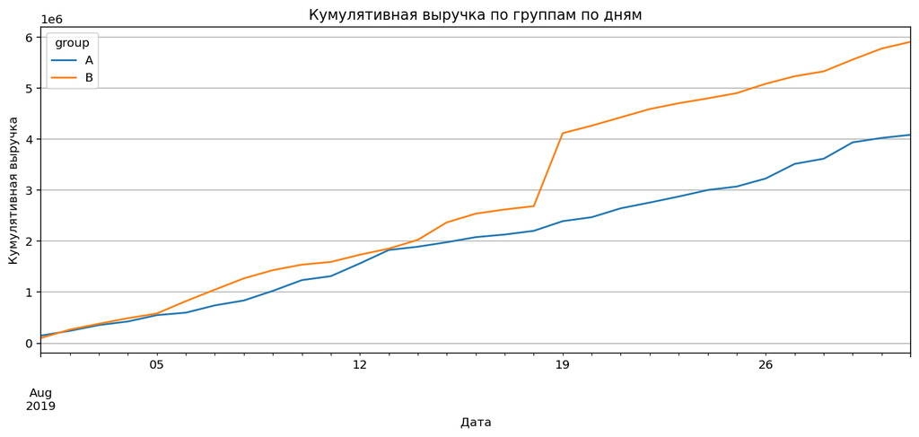

```python
orders.pivot_table(
    index='date',
    columns='group',
    values='revenue',
    aggfunc='sum').cumsum(axis=0).plot(grid=True,
                                       figsize=(13,5),
                                       title='Кумулятивная выручка по группам по дням'
                                    );
plt.xlabel('Дата');
plt.ylabel('Кумулятивная выручка');
```

```python
orders.groupby('group')['revenue'].sum()
```

```
group
A    4084803
B    5907760
Name: revenue, dtype: int64
```

Как видно на графике 19 августа 2019 года в группе B произошла крупная покупка, а далее покупки в группах происходили примерно одинаково. В результате общая выручка группы B превысила выручку группы А на 1.8 млн.

Проверим, что за покупка была в группе B 19 августа.

```python
orders[(orders['group'] == 'B') & (orders['date'] == '2019-08-19')]
```

|  | transactionId | visitorId | date | revenue | group |
| --- | --- | --- | --- | --- | --- |
| 315 | 1939633950 | 157579733 | 2019-08-19 | 2330 | B |
| 319 | 2414788465 | 2247745159 | 2019-08-19 | 1435 | B |
| 320 | 1652782757 | 2763027084 | 2019-08-19 | 1460 | B |
| 322 | 3154167297 | 2091902649 | 2019-08-19 | 250 | B |
| 363 | 2096847394 | 4251115836 | 2019-08-19 | 2500 | B |
| 367 | 1033377712 | 3860669668 | 2019-08-19 | 3990 | B |
| 368 | 3268879337 | 2536252163 | 2019-08-19 | 20026 | B |
| 423 | 4161654914 | 990904712 | 2019-08-19 | 11249 | B |
| 424 | 2609443403 | 2406916810 | 2019-08-19 | 470 | B |
| 425 | 590470918 | 1920142716 | 2019-08-19 | 1294500 | B |
| 426 | 19467429 | 2397843657 | 2019-08-19 | 2630 | B |
| 427 | 3019510679 | 2397843657 | 2019-08-19 | 1460 | B |
| 429 | 2436528253 | 1060341621 | 2019-08-19 | 1100 | B |
| 459 | 863448794 | 2738601405 | 2019-08-19 | 50 | B |
| 461 | 2683113224 | 154576532 | 2019-08-19 | 26550 | B |
| 463 | 4170537404 | 290022471 | 2019-08-19 | 16480 | B |
| 486 | 752294429 | 2758621772 | 2019-08-19 | 1130 | B |
| 523 | 1739748874 | 522292794 | 2019-08-19 | 4880 | B |
| 526 | 1654949825 | 1335154194 | 2019-08-19 | 500 | B |
| 527 | 1570513684 | 2837914161 | 2019-08-19 | 33405 | B |
| 529 | 90109939 | 2075769885 | 2019-08-19 | 3525 | B |

В группе B произошла очень крупная транзакция `590470918`, которая принесла выручки на 1,3 млн., что и сказалось на результате теста.

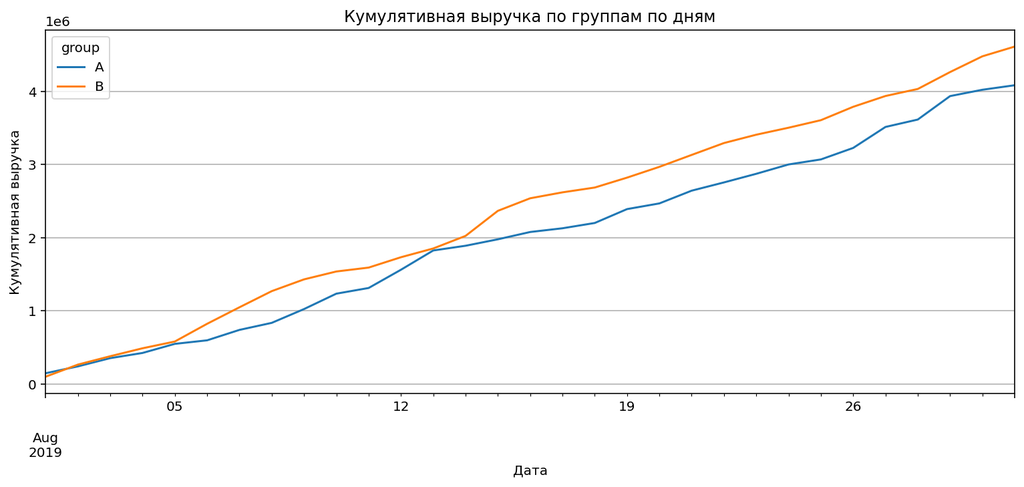

```python
orders.query('transactionId != "590470918"').pivot_table(
    index='date',
    columns='group',
    values='revenue',
    aggfunc='sum').cumsum(axis=0).plot(grid=True,
                                       figsize=(13,5),
                                       title='Кумулятивная выручка по группам по дням'
                                    );
plt.xlabel('Дата');
plt.ylabel('Кумулятивная выручка');
```

Если убрать эту транзакцию, кумулятивная выручка по группе В также лидирует, но уже не так значительно, продажи по двум группам шли в одном темпе, кроме начала месяца, когда группа В увеличила выручку. **Если судить только по кумулятивной выручке группа В показывает лучшие результаты**.

### 2. Исследование кумулятивного среднего чека по группам

Для расчета среднего чека расчитаем кумулятивную выручку и число заказов, а затем разделим одно на другое.

```python
revenues_cum = orders.pivot_table(
    index='date',
    columns='group',
    values='revenue',
    aggfunc='sum').cumsum(axis=0)
```

```python
n_orders_cum = orders.pivot_table(
    index='date',
    columns='group',
    values='transactionId',
    aggfunc='nunique').cumsum(axis=0)
```

```python
revenues_cum.head()
```

| group date | A | B |
| --- | --- | --- |
| 2019-08-01 | 148579 | 101217 |
| 2019-08-02 | 242401 | 266748 |
| 2019-08-03 | 354874 | 380996 |
| 2019-08-04 | 425699 | 489567 |
| 2019-08-05 | 549917 | 581995 |

```python
n_orders_cum.head()
```

| group date | A | B |
| --- | --- | --- |
| 2019-08-01 | 24 | 21 |
| 2019-08-02 | 44 | 45 |
| 2019-08-03 | 68 | 61 |
| 2019-08-04 | 84 | 78 |
| 2019-08-05 | 109 | 101 |

```python
mean_bill = revenues_cum.divide(n_orders_cum)
```

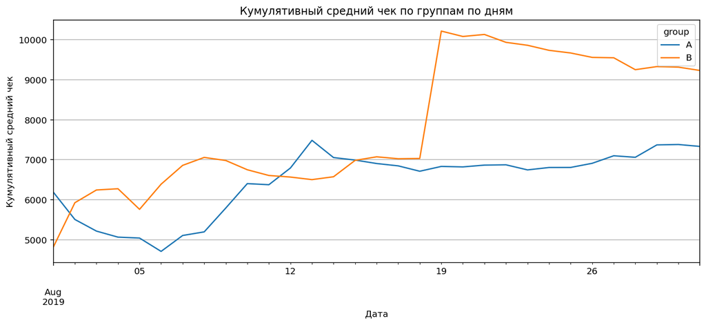

```python
mean_bill.plot(grid=True, figsize=(13,5),
                                       title='Кумулятивный средний чек по группам по дням');
plt.xlabel('Дата');
plt.ylabel('Кумулятивный средний чек');
```

По графику кумулятивного среднего чека также виден выброс в виде очень дорогой покупки 19 августа, который сместил все дальнейшие результаты. В то же время, даже на таком графике видно, что кумулятивный средний чек для группы В начинает снижаться к концу месяца, тогда как группа А постепенно растет. **По графику изменения кумулятивного среднего чека можно сделать вывод, что с учетом выброса группа В лидирует.**

### 3. Исследование относительного изменения кумулятивного среднего чека группы B к группе A.

Для расчета среднего чека расчитаем кумулятивную выручку и число заказов, а затем разделим одно на другое.

```python
mean_bill['rel'] = mean_bill['B'] / mean_bill['A'] - 1
```

```python
mean_bill.head()
```

| group date | A | B | rel |
| --- | --- | --- | --- |
| 2019-08-01 | 6190.791667 | 4819.857143 | -0.221447 |
| 2019-08-02 | 5509.113636 | 5927.733333 | 0.075987 |
| 2019-08-03 | 5218.735294 | 6245.836066 | 0.196810 |
| 2019-08-04 | 5067.845238 | 6276.500000 | 0.238495 |
| 2019-08-05 | 5045.110092 | 5762.326733 | 0.142161 |

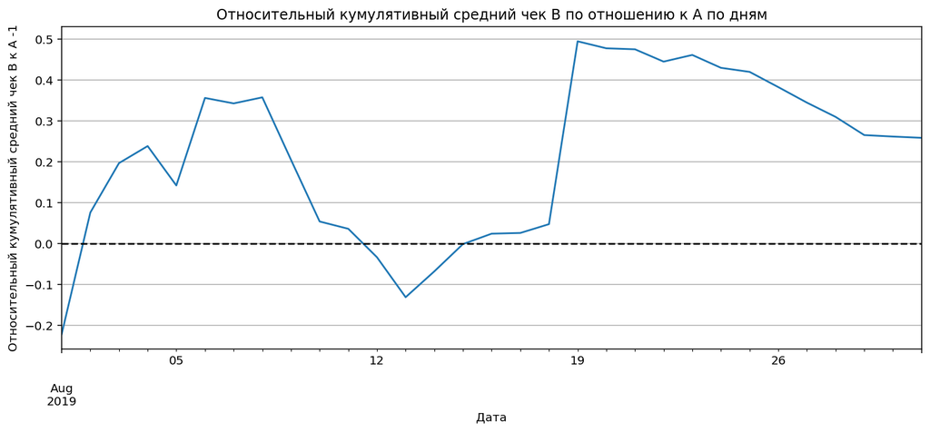

```python
mean_bill['rel'].plot(grid=True, figsize=(13,5),
                                       title='Относительный кумулятивный средний чек B по отношению к A по дням');
plt.xlabel('Дата');
plt.ylabel('Относительный кумулятивный средний чек B к A -1');
plt.axhline(y=0.0, color='black', linestyle='--');
```

По графику относительного кумулятивного среднего чека также виден выброс в виде очень дорогой покупки 19 августа, который сместил все дальнейшие результаты. В то же время, показатель группы В при любых условиях после 19 августа уменьшается к концу месяца. **По графику изменения относительного кумулятивного среднего чека можно сделать вывод, что с учетом выброса группа В лидирует, но имеет тенденцию к снижению относительно группы А.**

### 4. Исследование кумулятивной конверсии по группам

```python
n_orders_cum.head()
```

| group date | A | B |
| --- | --- | --- |
| 2019-08-01 | 24 | 21 |
| 2019-08-02 | 44 | 45 |
| 2019-08-03 | 68 | 61 |
| 2019-08-04 | 84 | 78 |
| 2019-08-05 | 109 | 101 |

```python
visitors_cum = visitors.pivot_table(
    index='date',
    columns='group',
    values='visitors',
    aggfunc='sum').cumsum(axis=0)
```

```python
visitors_cum.head()
```

| group date | A | B |
| --- | --- | --- |
| 2019-08-01 | 719 | 713 |
| 2019-08-02 | 1338 | 1294 |
| 2019-08-03 | 1845 | 1803 |
| 2019-08-04 | 2562 | 2573 |
| 2019-08-05 | 3318 | 3280 |

```python
conversion_cum = n_orders_cum.div(visitors_cum)
```

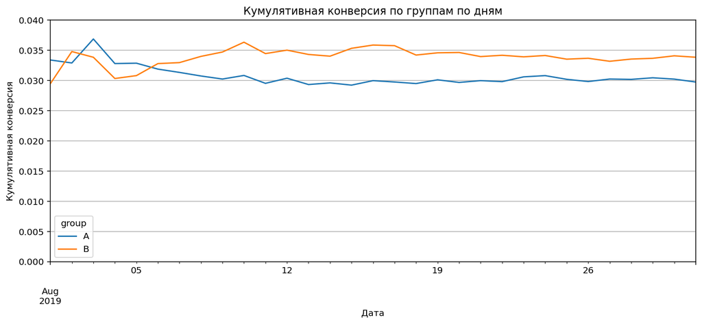

```python
conversion_cum.plot(grid=True, figsize=(13,5),
                                       title='Кумулятивная конверсия по группам по дням',
                                       ylim=(0, 0.040)
                                       );
plt.xlabel('Дата');
plt.ylabel('Кумулятивная конверсия');
```

График кумулятивной конверсии для групп установился на стабильных уровнях к концу месяца, причем группа В показала немногим лучший результат по сравнению с группой А (на 0.5 процентных пунктов). Интересно отметить, что группа В опередила группу А уже с 6-7 августа, а крупная покупка 19 августа не оказала действия на конверсию, так как не она не зависит от значений выручки. Зависимости стабилизовались, поэтому можно сказать, что времени для сбора данных для теста достаточно. **При сравнении кумулятивной конверсии группа В показывает лучший результат по сравнению с группой А на 0.5 процентных пункта.**

### 5. Исследование относительного изменения кумулятивной конверсии группы B к группе A

```python
conversion_cum['rel'] = conversion_cum['B'] / conversion_cum['A'] - 1
```

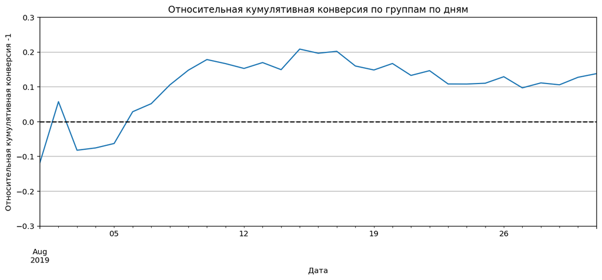

```python
conversion_cum['rel'].plot(grid=True, figsize=(13,5),
                                       title='Относительная кумулятивная конверсия по группам по дням',
                                       ylim=(-0.3, 0.3));
plt.xlabel('Дата');
plt.ylabel('Относительная кумулятивная конверсия -1');
plt.axhline(y=0.0, color='black', linestyle='--');
```

6-7 августа показатель группы В вырвался вперед, но немного снизился после 19 августа, но в последних числах месяца наметилась тенденция на рост. **В целом группа В показывает лучшие результаты, чем группа А, но показатель относительной конверсии все еще колеблется около стабильного значения, что может говорить о том, что требуется больше времени для А/В теста.**

### 6. Исследование количества заказов по пользователям

Посчитаем из исходных данных количество заказов у каждого пользователя.

```python
orders.head()
```

|  | transactionId | visitorId | date | revenue | group |
| --- | --- | --- | --- | --- | --- |
| 0 | 3667963787 | 3312258926 | 2019-08-15 | 1650 | B |
| 1 | 2804400009 | 3642806036 | 2019-08-15 | 730 | B |
| 2 | 2961555356 | 4069496402 | 2019-08-15 | 400 | A |
| 3 | 3797467345 | 1196621759 | 2019-08-15 | 9759 | B |
| 4 | 2282983706 | 2322279887 | 2019-08-15 | 2308 | B |

```python
n_orders_users = orders.groupby('visitorId')['transactionId'].nunique().reset_index()
```

```python
n_orders_users.head()
```

|  | visitorId | transactionId |
| --- | --- | --- |
| 0 | 5114589 | 1 |
| 1 | 6958315 | 1 |
| 2 | 8300375 | 2 |
| 3 | 11685486 | 1 |
| 4 | 39475350 | 1 |

Для наглядной визуализации с помощью точечного графика используем индекс в таблице как значения по оси X.

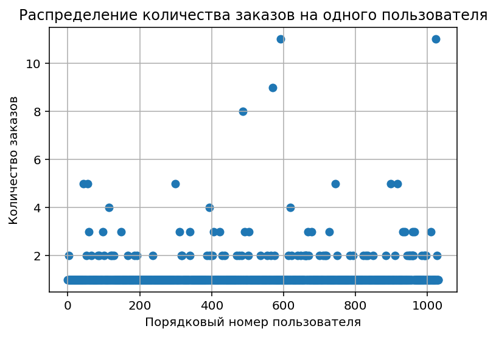

```python
plt.scatter(x=n_orders_users.index, y=n_orders_users['transactionId']);
plt.grid(True);
plt.title('Распределение количества заказов на одного пользователя');
plt.ylabel('Количество заказов');
plt.xlabel('Порядковый номер пользователя');
```

### 7. Поиск аномальных пользователей

```python
print(np.percentile(n_orders_users['transactionId'], [95, 99]))
```

```
[2. 4.]
```

Не более 5% пользователей делали более 2 заказов и не более 1% делали 4 покупок. **Для устранения выбросов логично выбрать границу в виде 2 заказов для отделения необычных пользователей из набора данных.**

### 8. Исследование стоимостей заказов

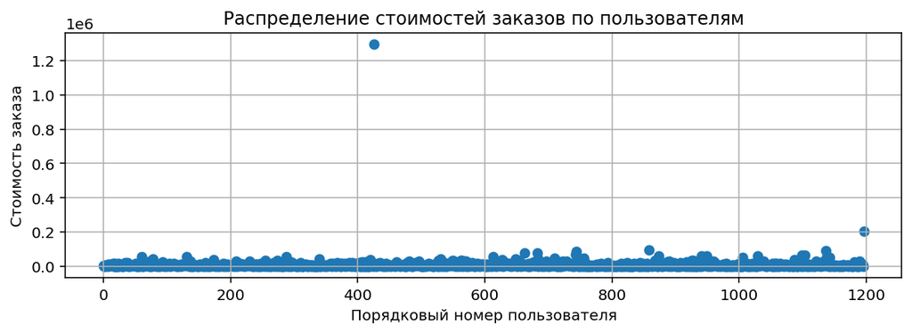

```python
plt.figure(figsize=(10,3));
plt.scatter(x=orders.index, y=orders['revenue']);
plt.grid(True);
plt.title('Распределение стоимостей заказов по пользователям');
plt.ylabel('Стоимость заказа');
plt.xlabel('Порядковый номер пользователя');
```

По точечному графику сразу стали видны пользователи, которые совершили очень дорогую покупку, очень сильно превышающую обычный уровень ниже 100 тыс. Такие выбросы оказывают влияние на расчеты среднего чека и другие метрики, включающие в себя значения выручки, а значит оказывают влияние на анализ А/В теста. **Большинство покупателей совершают покупки дешевле 100 тыс., но некоторые совершили очень дорогие покупки более 1 млн. Для чистоты анализа А/В теста следует устранить выбросы.**

### 9. Поиск аномальных заказов

```python
print(np.percentile(orders['revenue'], [95, 99]))
```

```
[28000.  58233.2]
```

Не более 5% заказов совершено на сумму более 28 тыс. и не более 1% на сумму более 58 тыс. **Для устранения выбросов логично выбрать границу в виде суммы выручки не более 28 тыс. для определения аномальных заказов в наборе данных.**

### 10. Исследование статистической значимости различий в конверсии между группами по «сырым» данным

Для статистического теста Манна-Уитни требуется собрать выборку из всех пользователей, сделавшими, либо не сделавшими заказ в группах. для этого нужно расчитать количество заказов для каждого покупатели и добавить нули до размера выборки по всем посетителям.

```python
orders_users_a = orders[orders['group']=='A'].groupby('visitorId')['transactionId'] \
                                            .nunique().reset_index()
orders_users_b = orders[orders['group']=='B'].groupby('visitorId')['transactionId'] \
                                            .nunique().reset_index()
```

```python
orders_users_a.head()
```

|  | visitorId | transactionId |
| --- | --- | --- |
| 0 | 8300375 | 1 |
| 1 | 11685486 | 1 |
| 2 | 54447517 | 1 |
| 3 | 66685450 | 1 |
| 4 | 78758296 | 1 |

```python
orders_users_b.head()
```

|  | visitorId | transactionId |
| --- | --- | --- |
| 0 | 5114589 | 1 |
| 1 | 6958315 | 1 |
| 2 | 8300375 | 1 |
| 3 | 39475350 | 1 |
| 4 | 47206413 | 1 |

```python
visitors.head()
```

|  | date | group | visitors |
| --- | --- | --- | --- |
| 0 | 2019-08-01 | A | 719 |
| 1 | 2019-08-02 | A | 619 |
| 2 | 2019-08-03 | A | 507 |
| 3 | 2019-08-04 | A | 717 |
| 4 | 2019-08-05 | A | 756 |

```python
visitors.groupby('group')['visitors'].sum().reset_index()
```

|  | group | visitors |
| --- | --- | --- |
| 0 | A | 18736 |
| 1 | B | 18916 |

```python
visitors_a = visitors.query('group == "A"').groupby('group')['visitors'].sum()['A']
```

```python
visitors_b = visitors.query('group == "B"').groupby('group')['visitors'].sum()['B']
```

```python
visitors_a
```

```
18736
```

```python
visitors_b
```

```
18916
```

Для каждой группы получили количество посетителей.

```python
orders_a = orders_users_a[['transactionId']]
```

```python
orders_a.head()
```

|  | transactionId |
| --- | --- |
| 0 | 1 |
| 1 | 1 |
| 2 | 1 |
| 3 | 1 |
| 4 | 1 |

```python
len(orders_a)
```

```
503
```

Все совершили заказы 503 покупателя из 18736 посетителей для группы А.

```python
zeros_a = pd.DataFrame(0, index=np.arange(visitors_a - len(orders_a)), columns=orders_a.columns)
```

```python
zeros_a
```

|  | transactionId |
| --- | --- |
| 0 | 0 |
| 1 | 0 |
| 2 | 0 |
| 3 | 0 |
| 4 | 0 |
| ... | ... |
| 18228 | 0 |
| 18229 | 0 |
| 18230 | 0 |
| 18231 | 0 |
| 18232 | 0 |

18233 rows × 1 columns

Получили список из недостающих нулей для посетителей без покупок. Объединим таблицы.

```python
sample_orders_a = pd.concat([orders_a, zeros_a], axis=0)
```

```python
sample_orders_a
```

|  | transactionId |
| --- | --- |
| 0 | 1 |
| 1 | 1 |
| 2 | 1 |
| 3 | 1 |
| 4 | 1 |
| ... | ... |
| 18228 | 0 |
| 18229 | 0 |
| 18230 | 0 |
| 18231 | 0 |
| 18232 | 0 |

18736 rows × 1 columns

```python
len(sample_orders_a)
```

```
18736
```

Получили готовый набор данных. Аналогично для группы В.

```python
orders_b = orders_users_b[['transactionId']]
```

```python
zeros_b = pd.DataFrame(0, index=np.arange(visitors_b - len(orders_b)), columns=orders_b.columns)
```

```python
sample_orders_b = pd.concat([orders_b, zeros_b], axis=0)
```

```python
len(sample_orders_b)
```

```
18916
```

Количества элементов сошлись, все в порядке.

Для статистически точной оценки различий между наборами данных применяются различные статистические тесты, параметрические (зависят от абсобтных значений величин в выборке, например тест Стьюдента) и непараметрические (сравнивают ранги значений вместо самих значений, например тест Манна-Уитни).

Хотя многие реальные процессы описываются нормальным распределением, количество заказов им не описывается, так как подавляющее большинство пользователей совершают малое число заказов.

Для формальной проверки выборки на нормальность можно применить критерий Шапиро-Уилка. Нулевой гипотезой в таком случае будет ситуация, что выборка нормальная, а альтернативной - что выборка нормальной не является. Критерий значимости примем за **0.05**.

```python
results_shapiro = shapiro(sample_orders_a)
```

```python
results_shapiro[1]
```

```
0.0
```

Получившийся *pvalue = 0* показывает, что нулевую гипотезу о том, что распределение выборки нормальное, нужно отбросить. Таким образом тест Стьюдента здесь неприменим, поэтому используем непараметрический тест Манна-Уитни.

В нашем случае нулевой гипотезой будет предположение, что выборки структурно равны, а альтернативной - что различны. Выберем **критический уровень значимости 0.05** и установим параметр альтернативной гипотезы `two-sided` для расчета различий в целом.

```python
pvalue = mannwhitneyu(sample_orders_a, sample_orders_b, alternative='two-sided')[1]
```

```python
pvalue
```

```
0.016792355056752608
```

Для сравнения конверсий достаточно сравнить среднее арифметическое по выборкам, так как сумма по столбцу в получившейся таблице дает количество заказов, а количество строк - число посетителей.

```python
rel_conversion = sample_orders_b.mean()[0]/sample_orders_a.mean()[0] - 1
```

```python
rel_conversion
```

```
0.13807884655320146
```

**В результате с выбранным критерием значимости 0.05 получившийся *pvalue = 0.016* его не превышает, что позволяет сделать вывод, что различия в выборках есть и они статистически значимы. Группа В имеет конверсию на 14% выше, чем группа А по сырым данным.**

### 11. Исследование статистической значимости различий в среднем чеке заказа между группами по «сырым» данным

Для подготовки наборов данных для теста достаточно выбрать значения выручки для групп.

```python
sample_revenue_a = orders.query('group == "A"')['revenue']
```

```python
sample_revenue_b = orders.query('group == "B"')['revenue']
```

```python
sample_revenue_a.head()
```

```
2     400
7     1044
8     13710
10    4008
12    7370
Name: revenue, dtype: int64
```

```python
sample_revenue_b.head()
```

```
0    1650
1    730
3    9759
4    2308
5    2210
Name: revenue, dtype: int64
```

Выберем критерий значимости также 0.05.

```python
pvalue_revenue = mannwhitneyu(sample_revenue_a, sample_revenue_b)[1]
```

```python
pvalue_revenue
```

```
0.3646454927716229
```

Значение *pvalue* превышает выбранный критерий, поэтому статистически значимой разницы в выручке по группам нет.

Проверим также относительную разницу среднего чека.

```python
sample_revenue_b.mean()/sample_revenue_a.mean()-1
```

```
0.2587136699126005
```

Так как тест Манна-Уитни непараметрический, то ему безразличны выбросы значений в выборках, поэтому на "грязных" данных с выбросами он дает верный результат, даже если сравнение средних метрик дает противоположный результат.

**Как видно, средний чек группы В превышает средний чек группы А на 26%, но статистической разницы между выборками нет.**

### 12. Исследование статистической значимости различий в конверсии между группами по «очищенным» данным

Для очистки выборки от аномальных пользователей выберем критерии **не более 2 заказов и выручка не более 28 тыс**.

Вычленим идентификаторы таких пользователей из каждой группы и объединим в один столбец.

```python
users_many_orders = pd.concat([orders_users_a.query('transactionId > 2')['visitorId'],
                               orders_users_b.query('transactionId > 2')['visitorId']],
                                axis=0)
```

```python
len(users_many_orders)
```

```
24
```

Таких покупателей всего 24.

```python
users_expensive_orders = orders.query('revenue > 28000')['visitorId']
```

```python
len(users_expensive_orders)
```

```
60
```

Пользователей с дорогими покупками всего 60 из всего числа. Объединим таких пользователей в один столбец и удалим возможные дубликаты из-за пересечений множеств.

```python
abnormal_users = pd.concat([users_many_orders, users_expensive_orders], axis=0).drop_duplicates()
```

```python
abnormal_users.head()
```

```
18     199603092
23     237748145
68     611059232
146    1230306981
189    1614305549
Name: visitorId, dtype: int64
```

```python
len(abnormal_users)
```

```
74
```

В результате получили 74 идентификатора пользователей, который совершили необычные покупки.

Подготовим новые выборки для теста Манна-Уитни.

```python
orders_users_a_filtered = orders_users_a[~orders_users_a['visitorId'].isin(abnormal_users)]
```

```python
orders_users_b_filtered = orders_users_b[~orders_users_b['visitorId'].isin(abnormal_users)]
```

```python
zeros_a_filtered = pd.DataFrame(0, index=np.arange(visitors_a - len(orders_users_a_filtered['transactionId'])),
                                columns=['transactionId'])
```

```python
zeros_b_filtered = pd.DataFrame(0, index=np.arange(visitors_b - len(orders_users_b_filtered['transactionId'])),
                                columns=['transactionId'])
```

```python
sample_orders_a_filtered = pd.concat([orders_users_a_filtered[['transactionId']], zeros_a_filtered], axis=0)
```

```python
sample_orders_b_filtered = pd.concat([orders_users_b_filtered[['transactionId']], zeros_b_filtered], axis=0)
```

Для рассчета статистической значимости также применим критерий Манна-Уитни с выбранным **критерием значимости 0.05** и двусторонней гипотезой. Нулевая гипотеза состоит в том, что структурной разницы в выборках нет, а альтернативная - что есть.

```python
pvalue_filtered = mannwhitneyu(sample_orders_a_filtered, sample_orders_b_filtered,
                               alternative='two-sided')[1]
```

```python
pvalue_filtered
```

```
0.013063114767059361
```

```python
rel_conversion_filtered = sample_orders_b_filtered.mean()[0]/sample_orders_a_filtered.mean()[0] - 1
```

```python
rel_conversion_filtered
```

```
0.17266633792572206
```

**В отфильтрованном от аномальных покупателей наборах *pvalue = 0.013* стал еще ниже и все также меньше выбранного критического значени 0.05, а значит нулевую гипотезу нужно отбросить. Это позволяет сделать вывод, что различия в выборках есть и они статистически значимы также и в отфильтрованных данных. Конверсия для группы В даже увеличилась и стала на 17% выше, чем в группе А.**

### 13. Исследование статистической значимости различий в среднем чеке заказа между группами по «очищенным» данным

```python
sample_revenue_a_filtered = orders[~orders['visitorId'].isin(abnormal_users)].query('group == "A"')['revenue']
```

```python
sample_revenue_b_filtered = orders[~orders['visitorId'].isin(abnormal_users)].query('group == "B"')['revenue']
```

Для рассчета статистической значимости также применим критерий Манна-Уитни с выбранным **критерием значимости 0.05** и двусторонней гипотезой. Нулевая гипотеза состоит в том, что структурной разницы в выборках нет, а альтернативная - что есть.

```python
pvalue_revenue_filtered = mannwhitneyu(sample_revenue_a_filtered, sample_revenue_b_filtered,
                                      alternative='two-sided')[1]
```

```python
pvalue_revenue_filtered
```

```
0.738481751314565
```

Значение *pvalue* превышает выбранный критерий, поэтому нулевую гипотезу нельзя отбросить и значит статистически значимой разницы в выручке по группам нет.

Проверим также относительную разницу среднего чека.

```python
sample_revenue_b_filtered.mean()/sample_revenue_a_filtered.mean()-1
```

```
-0.019624288331982598
```

**В отфильтрованных от аномальных пользователей выборках статистической разницы все также нет (*pvalue = 0.74*). В то же время, так как мы избавились от выбросов, разница в средних чеках стала всего лишь 2%, причем группа B хуже группы А.**

## Часть 3. Общий вывод и рекомендации

В результате работы было сделано следующее:

Как итог, можно предположить, что результаты А/В теста можно использовать в случае, если компании важно увеличить конверсию. Но, по-видимому, изменения, примененные в сегменте В вызывают приток новых покупателей, которые не делают большие заказы, а наоборот снижают метрику среднего чека. В совокупности увеличение конверсии приводит к увеличению общей выручки компании, несмотря на незначительное уменьшение среднего чека.

Так как в изначальной задаче исследования предполагась цель по увеличению общей выручки в конечном итоге, посмотрим на распеределение кумулятивной выручки по группам без аномальных покупателей.

```python
orders_filtered = orders[~orders['visitorId'].isin(abnormal_users)]
```

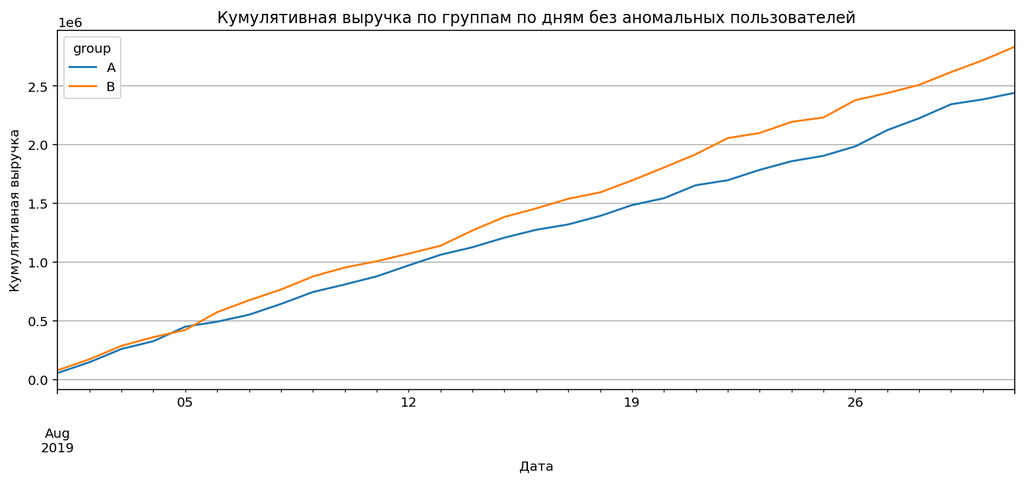

```python
orders_filtered.pivot_table(
    index='date',
    columns='group',
    values='revenue',
    aggfunc='sum').cumsum(axis=0).plot(grid=True,
                                       figsize=(13,5),
                                       title='Кумулятивная выручка по группам по дням без аномальных пользователей'
                                    );
plt.xlabel('Дата');
plt.ylabel('Кумулятивная выручка');
```

```python
orders_filtered.groupby('group')['revenue'].sum().reset_index()
```

|  | group | revenue |
| --- | --- | --- |
| 0 | A | 2443806 |
| 1 | B | 2836522 |